# Tidybiology Final Project

Nadia Eliora

November 05, 2023

## Setup

```r
library(tidyverse)
library(RImageJROI)
library(here)
library(gridExtra)
library(DescTools)
library(ggpubr)
```

## Introduction & Goal

I study the formation of pillars during morphogenesis of semicircular canals (organs in the inner ear that sense rotational acceleration) in zebrafish. On the left is an example of a normal wildtype anterior and posterior pillar. On the right are abnormal pillars in crispant* embryos. Their medial surfaces are traced in yellow.

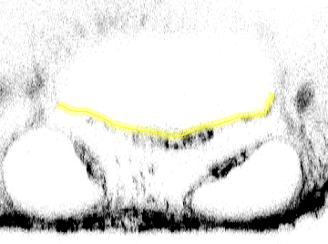

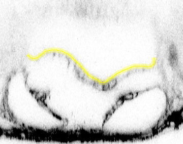

I noticed that the wildtype pillars have a very tapered shape, while the crispant pillars appear “bumpy” (for lack of a better term). However, this is a qualitative observation, not a quantitative measurements. In this project, **I wanted to develop a pipeline to quantitatively measure pillar “bumpiness”** to support my qualitative observation. I hope to use this pipeline for my future analysis.

## Import data

To build this pipeline, I first focused on one crispant (above, right image).

The first thing I did was trace the medial pillar surface on ImageJ and save the ROI (region of interest). I then extracted the ROI coordinates and did a few transformations to help me visualize the data. Namely, I multiplied the y values by -1 (y_neg) and shifted x to start at 0 (x_new).

```
## Rows: 362
## Columns: 4
## $ x     <dbl> 54, 55, 55, 56, 56, 57, 57, 58, 58, 59, 60, 61, 62, 63, 64, 64, …
## $ y     <dbl> 108, 108, 109, 109, 110, 110, 111, 111, 112, 112, 113, 114, 114,…
## $ y_neg <dbl> -108, -108, -109, -109, -110, -110, -111, -111, -112, -112, -113…
## $ x_new <dbl> 0, 1, 1, 2, 2, 3, 3, 4, 4, 5, 6, 7, 8, 9, 10, 10, 11, 12, 13, 14…
```

Below is a visualization of my transformed data, which mirrors the ROI seen in the image above (right)

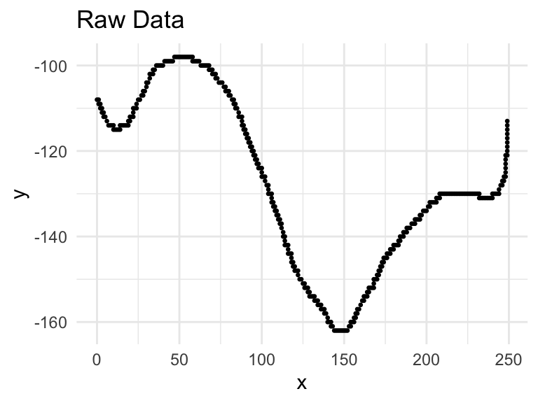

## Exploratory Data Analysis

### Method 1.1: Polynomial Regression

The first method I tried was based on polynomial regressions. I wanted to fit my data to a polynomial line, then find the average area of its derivative. I reasoned that if we compared the polynomial functions of crispants to wildtype pillars, the derivatives about the points of inflection would be greater in crispants than wildtype.

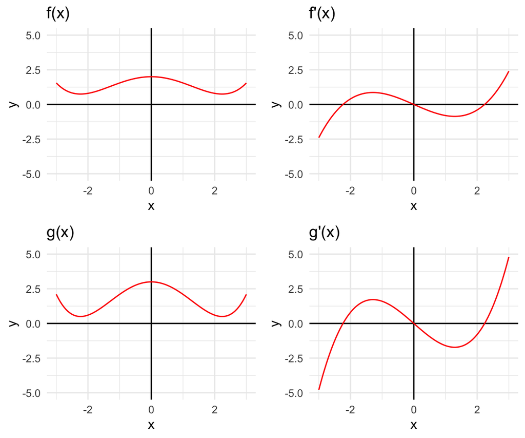

The average area under the curve (aAUC) of their first derivative in an interval [a,b] with x-intercepts at {x1, x2, …, xn} is given by the equation:
$$aAUC = \frac{1}{b-a} \left[
|\int_{a}^{x_1}f'(x)dx| + |\int_{x_1}^{x_2}f'(x)dx| + ... +
|\int_{x_{n}}^{b}f'(x)dx| \right]$$
Using this formula, I found that **aAUC for f’(x) is 0.51** and the **aAUC for g’(x) is 1.03**, showing that the aAUC of the first derivative of a “bumpier” curve is greater than that of a “smoother” curve. I tried to apply this logic to my own data.

### Method 1.2: Polynomial Regression Exploration

To find the best fit polynomial line, I used stat_smooth in ggplot. I compared the best fit lines (red) of orders 5-8, and selected order 7 (because order 7 and 8 look identical).

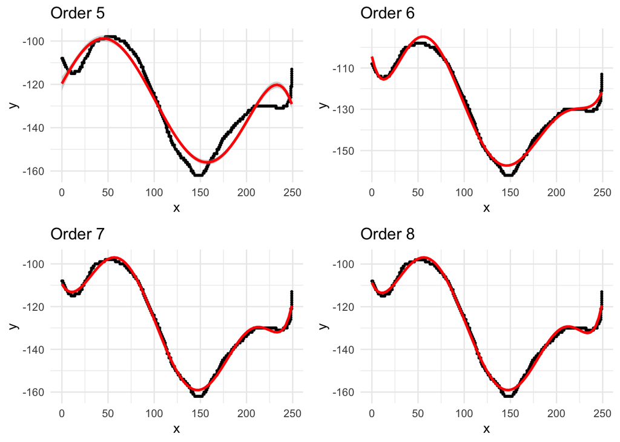

I used the *lm* function to find the linear model of the best fit seventh-order polynomial. To test that this model is correct, I used it to predict the coordinates of y based on x.

```
## Rows: 362
## Columns: 2
## $ x <dbl> 0, 1, 1, 2, 2, 3, 3, 4, 4, 5, 6, 7, 8, 9, 10, 10, 11, 12, 13, 14, 14…
## $ y <dbl> -109.4216, -110.1363, -110.1363, -110.7681, -110.7681, -111.3196, -1…
```

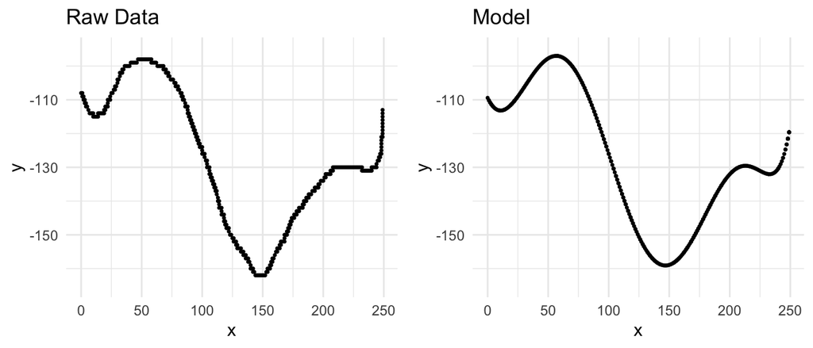

From this model, I extracted the polynomial coefficients into a dataframe.

```
## Rows: 8
## Columns: 1
## $ coef_ori <dbl> -1.094216e+02, -7.570870e-01, 4.283310e-02, -4.448502e-04, -2…
```

Then, I used the coefficients of the model to find the coefficients of the first derivative and stored it in the same dataframe.

```
## Rows: 8
## Columns: 2
## $ coef_ori <dbl> -1.094216e+02, -7.570870e-01, 4.283310e-02, -4.448502e-04, -2…
## $ coef_1st <dbl> 0.000000e+00, -7.570870e-01, 8.566619e-02, -1.334551e-03, -9.…
```

Next, I used the coefficients to build a new dataframe (dfd) that calculates y from x based on the function of the first derivative

```
## Rows: 362
## Columns: 2
## $ x <dbl> 0, 1, 1, 2, 2, 3, 3, 4, 4, 5, 6, 7, 8, 9, 10, 10, 11, 12, 13, 14, 14…
## $ y <dbl> -0.75708701, -0.67276416, -0.67276416, -0.59116121, -0.59116121, -0.…
```

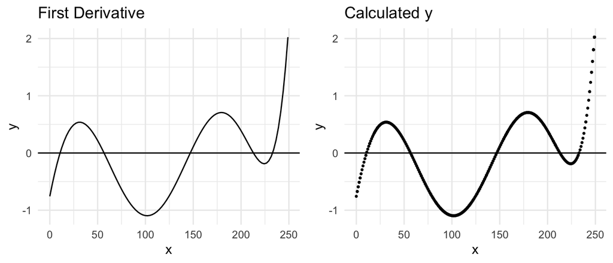

With this new dataframe (dfd) and the AUC function from the DescTools package, I calculated the area under the curve. After finding the area, I divided the area by the interval to find the average AUC.

```r
x_max <- max(dfd$x)
area <- AUC(x = dfd$x, y = dfd$y,
            absolutearea = TRUE)
aAUC.crispant <- area/(x_max)
```

This gave an **average AUC of 0.5079841**. When I did the same thing for normal pillars (top image, left), the **average AUC was 0.3214668**. So, the crispant pillars have a greater average AUC than wildtype pillars, at least for the two embryos I used to build this pipeline. This result encouraged me to use this method for my other embryos.

### Method 1.3: Polynomial Regression Results

I automated this method for all my embryos and generated a dataframe that contains an arbitrary EmbryoID, the type of embryo, the AUC, interval, and average AUC. For all embryos, the model is an order 7 polynomial.

```
## Rows: 9
## Columns: 5
## $ EmbryoID <dbl> 1, 2, 3, 4, 5, 6, 7, 8, 9
## $ Type     <chr> "Crispant", "Crispant", "Crispant", "Crispant", "Crispant", "…
## $ AUC      <dbl> 126.48804, 79.11698, 99.09045, 60.74125, 116.68955, 75.86616,…
## $ Interval <dbl> 249, 263, 266, 251, 245, 236, 267, 248, 258
## $ aAUC     <dbl> 0.5079841, 0.3008250, 0.3725205, 0.2419970, 0.4762839, 0.3214…
```

Out of curiosity, I also calculated the average AUC of the second derivative and third derivative. Then, I plotted the average AUC for wildtype and crispant embryos, generating these graphs:

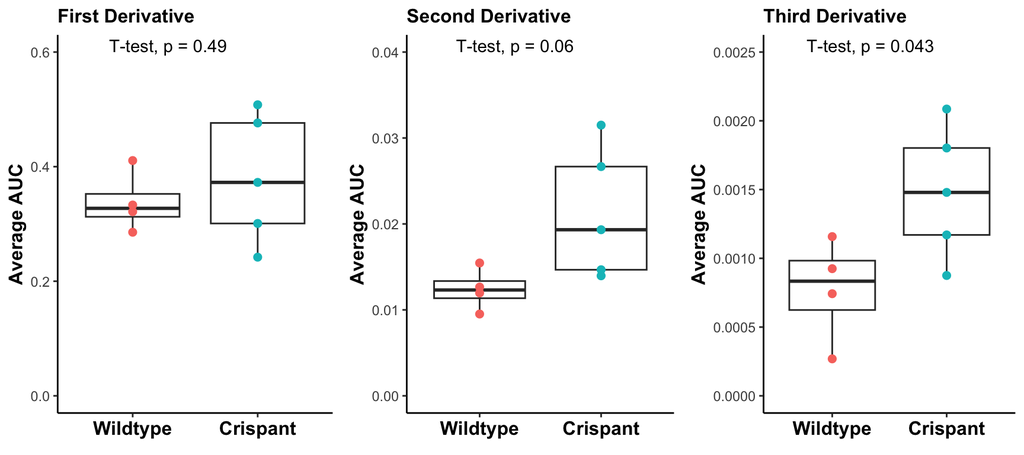

Notice that with each derivative, the p-value decreases. I’m not sure how to interpret this trend, and I’m concerned that if I arbitrarily choose which derivative to use, I would be lying with statistics. Thus, I think I need to consult with a mathematician, physicist, or anyone who has a stronger math intuition/understanding than me to evaluate the validity of this method.

### Method 2: R-squared

Another approach is to think of the pillars as parabolas. I can then approximate “bumpiness” as how much a quadratic model deviates from the raw data. In other words, I want to find the R-squared value. For example, the raw data (black) and best fit quadratic model (red) for the pillars in the introduction are shown below.

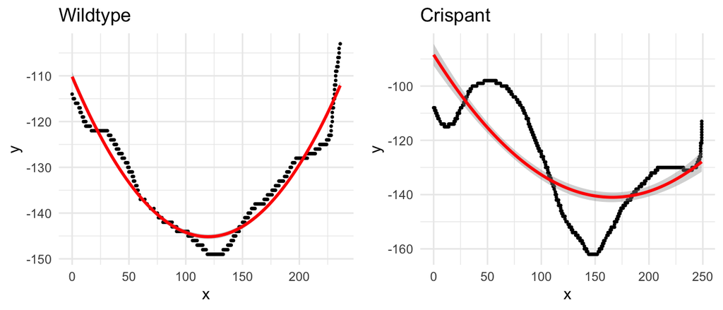

Visually, you can see that the model deviates more from the raw data in crispant than wildtype pillars. The *lm* function gives you the R-squared value of these models: the **R-squared for wildtype is 0.9327934** while the **R-squared for crispants is 0.5474645**. A higher R-squared indicates a “smoother” surface, while a lower R-squared indicates a “bumpier” surface.

I automated this new pipeline for all my embryos, generating the new dataframe below:

```
##   EmbryoID     Type       Rsq
## 1        1 Crispant 0.5474645
## 2        2 Crispant 0.6337620
## 3        3 Crispant 0.8482134
## 4        4 Crispant 0.6232303
## 5        5 Crispant 0.5158073
## 6        6 Wildtype 0.9327934
## 7        7 Wildtype 0.8074805
## 8        8 Wildtype 0.9498817
## 9        9 Wildtype 0.9497608
```

## Final Graph

I plotted the R-squared value for wildtype and crispant embryos. The average R-squared is greater in wildtype than crispants, indicating that the wildtype pillars are “smoother”, while the crispant pillars are “bumpier”. This difference is statistically significant.

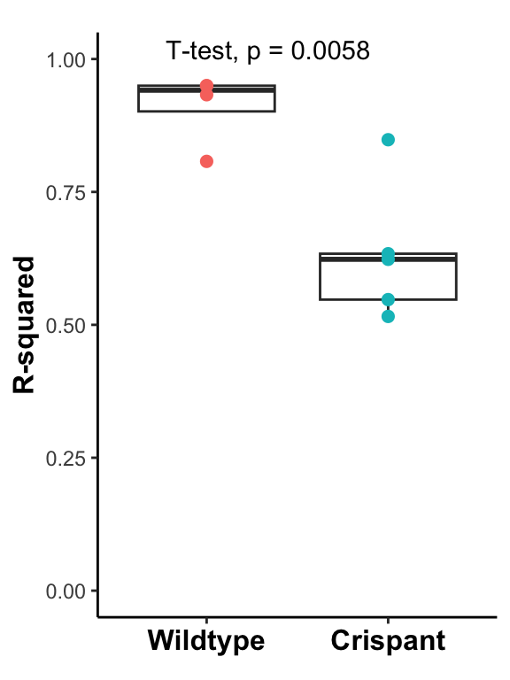

## Conclusions

From this project, I draw two main conclusions:  
1. At its current state, the polynomial regression approach (Method 1) is not suitable for measuring pillar “bumpiness”.  
2. The R-squared approach (Method 2) is a simpler, more straightforward way to measure pillar “bumpiness”. Thus, I am more inclined to use this approach moving forward.

In general, this project reminded me that I need to be careful and mindful of how I analyze my data. I want to consult more with others more knowledgeable in geometry to truly evaluate whether or not Method 2 is a valid way of representing pillar morphology.

## Prioritized follow-up studies

With these results, I want to do two things in the near future:  
1. I need to gather more data points to populate the graphs.  
2. Currently, this pipeline accounts for 2D curvature. Thus, measurements are affected by how I orient my embryos and which image slices I choose, which can introduce bias. Additionally, this 2D method does not fully capture the 3D architecture of the pillars. Thus, my next step is adapting this pipeline to measure curvature in 3D.

## Acknowledgements

Thank you to Matt Hirschey (PhD), Akshay Bareja (DPhil), and Telmo Llanga for leading this course. I especially want to thank Akshay and Pol for helping me troubleshoot last Friday before and after class. I’m not sure why my code works now, but I’m glad it does!

For this project, I used the *tidyverse* package in many steps in my pipeline. I used *RImageJROI* and *here* for importing data, *gridExtra* for organizing figures, *DescTools* to find the area under the curves, and *ggpubr* for statistical tests.

### Footnotes

*Crispants are the F0 generation of embryos where certain genes are targeted with CRISPR/Cas9.